# tarea3

Andres Gonzalez

31/10/2019

## Parte I

Cargue el paquete 𝑑𝑎𝑡𝑜𝑠 en R el cual contiene varias bases de datos que pueden ser utilizadas para el trabajo con los temas del curso. Trabaje con los datos de 𝑣𝑢𝑒𝑙𝑜𝑠 y realice lo siguiente:

**a.** Brevemente explique de qué tratan los datos

Los datos contienen informacion sobre vuelos realizados en el año 2013 por diferentes aerolineas. Además contiene horarios de salida y llegada (programada y real), distancia, tiempo de vuelo, fecha, origen y destino.

```r
summary(vuelos)
```

```
##       anio           mes              dia        horario_salida
##  Min.   :2013   Min.   : 1.000   Min.   : 1.00   Min.   :   1
##  1st Qu.:2013   1st Qu.: 4.000   1st Qu.: 8.00   1st Qu.: 907
##  Median :2013   Median : 7.000   Median :16.00   Median :1401
##  Mean   :2013   Mean   : 6.549   Mean   :15.71   Mean   :1349
##  3rd Qu.:2013   3rd Qu.:10.000   3rd Qu.:23.00   3rd Qu.:1744
##  Max.   :2013   Max.   :12.000   Max.   :31.00   Max.   :2400
##                                                  NA's   :8255
##  salida_programada atraso_salida     horario_llegada llegada_programada
##  Min.   : 106      Min.   : -43.00   Min.   :   1    Min.   :   1
##  1st Qu.: 906      1st Qu.:  -5.00   1st Qu.:1104    1st Qu.:1124
##  Median :1359      Median :  -2.00   Median :1535    Median :1556
##  Mean   :1344      Mean   :  12.64   Mean   :1502    Mean   :1536
##  3rd Qu.:1729      3rd Qu.:  11.00   3rd Qu.:1940    3rd Qu.:1945
##  Max.   :2359      Max.   :1301.00   Max.   :2400    Max.   :2359
##                    NA's   :8255      NA's   :8713
##  atraso_llegada      aerolinea             vuelo      codigo_cola
##  Min.   : -86.000   Length:336776      Min.   :   1   Length:336776
##  1st Qu.: -17.000   Class :character   1st Qu.: 553   Class :character
##  Median :  -5.000   Mode  :character   Median :1496   Mode  :character
##  Mean   :   6.895                      Mean   :1972
##  3rd Qu.:  14.000                      3rd Qu.:3465
##  Max.   :1272.000                      Max.   :8500
##  NA's   :9430
##     origen            destino           tiempo_vuelo     distancia
##  Length:336776      Length:336776      Min.   : 20.0   Min.   :  17
##  Class :character   Class :character   1st Qu.: 82.0   1st Qu.: 502
##  Mode  :character   Mode  :character   Median :129.0   Median : 872
##                                        Mean   :150.7   Mean   :1040
##                                        3rd Qu.:192.0   3rd Qu.:1389
##                                        Max.   :695.0   Max.   :4983
##                                        NA's   :9430
##       hora           minuto        fecha_hora
##  Min.   : 1.00   Min.   : 0.00   Min.   :2013-01-01 05:00:00
##  1st Qu.: 9.00   1st Qu.: 8.00   1st Qu.:2013-04-04 13:00:00
##  Median :13.00   Median :29.00   Median :2013-07-03 10:00:00
##  Mean   :13.18   Mean   :26.23   Mean   :2013-07-03 05:22:54
##  3rd Qu.:17.00   3rd Qu.:44.00   3rd Qu.:2013-10-01 07:00:00
##  Max.   :23.00   Max.   :59.00   Max.   :2013-12-31 23:00:00
##
```

```r
head(vuelos)
```

```
## # A tibble: 6 x 19
##    anio   mes   dia horario_salida salida_programa~ atraso_salida
##   <int> <int> <int>          <int>            <int>         <dbl>
## 1  2013     1     1            517              515             2
## 2  2013     1     1            533              529             4
## 3  2013     1     1            542              540             2
## 4  2013     1     1            544              545            -1
## 5  2013     1     1            554              600            -6
## 6  2013     1     1            554              558            -4
## # ... with 13 more variables: horario_llegada <int>,
## #   llegada_programada <int>, atraso_llegada <dbl>, aerolinea <chr>,
## #   vuelo <int>, codigo_cola <chr>, origen <chr>, destino <chr>,
## #   tiempo_vuelo <dbl>, distancia <dbl>, hora <dbl>, minuto <dbl>,
## #   fecha_hora <dttm>
```

**b.** Realice un gráfico de barras verticales con alguna de las variables presentes en el dataset vuelos. Esta variable debe cumplir los requerimientos explicados en clase

En el sigueinte grafico se observa que durante horas de la mañana entre 12:01AM a 5AM la cantidad de vuelos es bastante baja

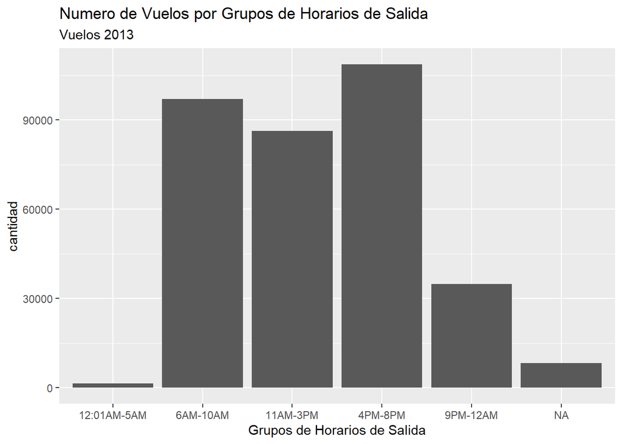

```r
vuelos$mes <- format(vuelos$fecha_hora, format="%B")
#ggplot(data = vuelos) +
#  geom_bar(mapping = aes(x = horario_salida))

labs <- c("12:01AM-5AM", "6AM-10AM", "11AM-3PM", "4PM-8PM", "9PM-12AM")

vuelos$horario_salida_grupos <- cut(vuelos$horario_salida, breaks = c(seq(1, 2001, by = 500), Inf), labels = labs, right = FALSE)

ggplot(data = vuelos) +
  geom_bar(mapping = aes(x = horario_salida_grupos)) +
  labs(title = "Numero de Vuelos por Grupos de Horarios de Salida",
       subtitle = "Vuelos 2013",
       x = "Grupos de Horarios de Salida",
       y = "cantidad")
```

**c.** Realice un gráfico de barras horizontal con alguna de las variables. Al igual que el caso anterior, debe elegir una variable que se ajuste a los requerimientos discutidos en clase para este tipo de gráficos.

En el siguiente grafico se observa 6 aerolineas con muy pocos vuelos, y podemos ver que la aerolinea UA es la que realiza más vuelos

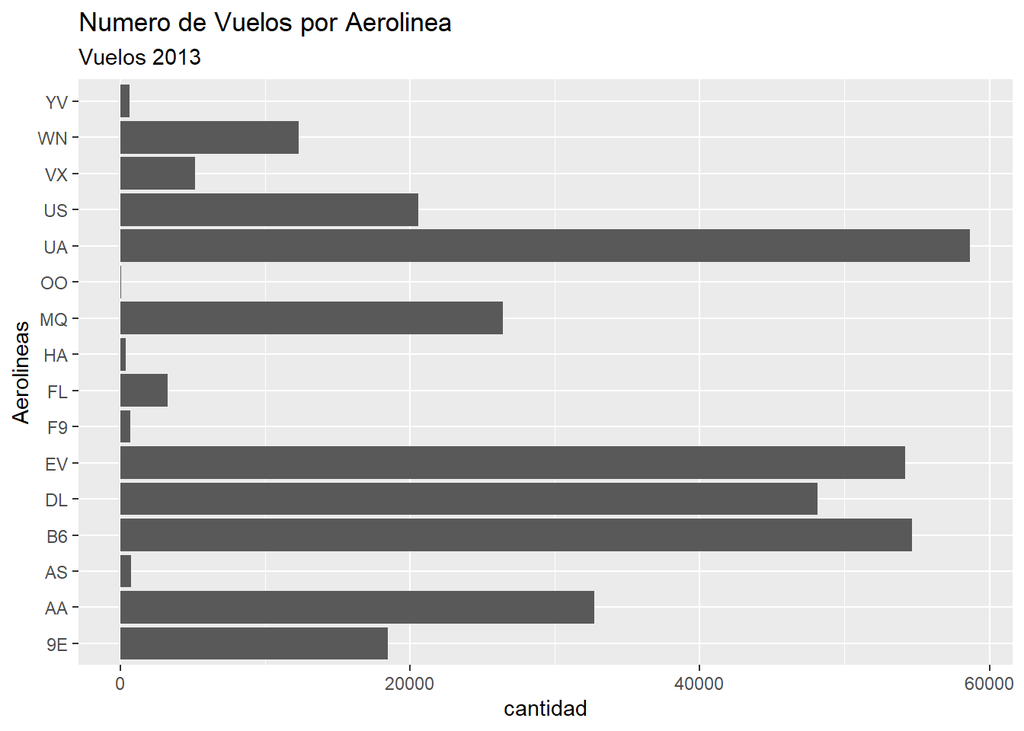

```r
ggplot(data = vuelos) +
  geom_bar(mapping = aes(x = aerolinea)) +
  coord_flip() +
  labs(title = "Numero de Vuelos por Aerolinea",
       subtitle = "Vuelos 2013",
       x = "Aerolineas",
       y = "cantidad")
```

**d.** Elija una de las variables y construya un gráfico de pastel. La variable debe tener las condiciones apropiadas. Tome en cuenta que para cada gráfico debe considerar las recomendaciones estudiadas en clases, las cuáles las pueden encontrar en la presentación. Para cada uno de los gráficos, haga una breve interpretación de lo observado.

En este grafico podemos notar que casi no hay diferencia entre la cantidad de vuelos y el origin del mismo

```r
vuelos_dat <- vuelos %>%
  group_by(origen) %>% # agrupar todo por clase
summarise(conteo = n())
vuelos_dat
```

```
## # A tibble: 3 x 2
##   origen conteo
##   <chr>   <int>
## 1 EWR    120835
## 2 JFK    111279
## 3 LGA    104662
```

```r
count.data <- vuelos_dat %>%
  arrange(desc(conteo)) %>%
  mutate(porcent = round(conteo/sum(conteo)*100,1))
count.data
```

```
## # A tibble: 3 x 3
##   origen conteo porcent
##   <chr>   <int>   <dbl>
## 1 EWR    120835    35.9
## 2 JFK    111279    33
## 3 LGA    104662    31.1
```

```r
count.data <- count.data %>%
  arrange(desc(porcent)) %>%
  mutate(lab.ypos = cumsum(porcent) - 0.5*porcent)
count.data
```

```
## # A tibble: 3 x 4
##   origen conteo porcent lab.ypos
##   <chr>   <int>   <dbl>    <dbl>
## 1 EWR    120835    35.9     18.0
## 2 JFK    111279    33       52.4
## 3 LGA    104662    31.1     84.4
```

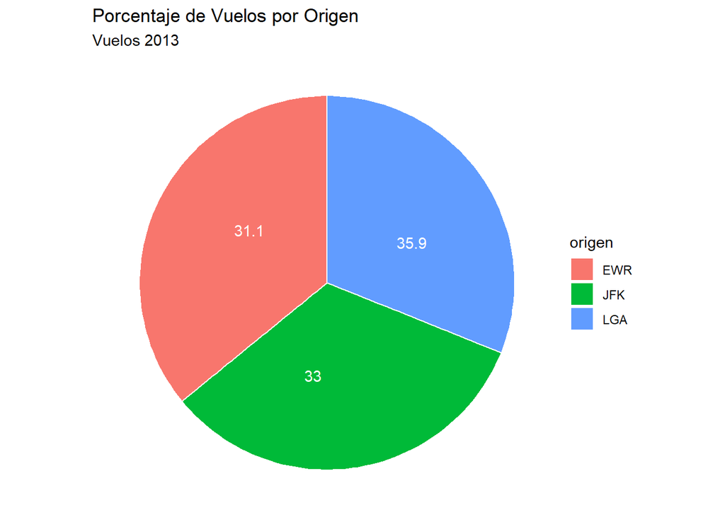

```r
ggplot(count.data, aes(x = "", y = porcent, fill = origen)) +
  geom_bar(width = 1, stat = "identity", color = "white") +
  coord_polar("y", start = 0)+
  geom_text(aes(y = lab.ypos, label = porcent), color = "white") +
  theme_void() +
  labs(title = "Porcentaje de Vuelos por Origen",
       subtitle = "Vuelos 2013")
```

## II Parte

**1.** Suponga que el 30% de los estudiantes del ITCR son mujeres. Si se toma una muestra de 10 mujeres al azar.

**a.** Escriba la fórmula de la distribución que modela esta situación (2pts)

$$p=0.3$$
$$q=0.7$$

$$p(x)=\binom{n}{x}p^{x}q^{n-x}$$
$$p(x)=\binom{10}{x}0.3^{x}0.7^{10-x}$$

**b.** ¿Cuál es la probabilidad de que en la muestra haya al menos 4 mujeres?

```r
#usando pbinom
pbinom(3, size = 10, prob = 0.3, lower.tail = FALSE)
```

```
## [1] 0.3503893
```

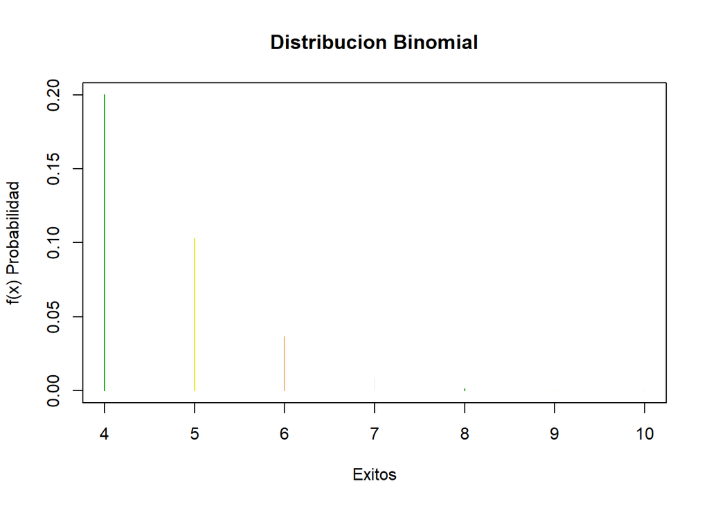

```r
#usando dbinom
prob <- dbinom(c(4:10), size=10, prob=0.3)
plot(c(4:10), prob, type="h", xlab="Exitos", ylab="f(x) Probabilidad", main="Distribucion Binomial", col=terrain.colors(4))
```

```r
sum(prob)
```

```
## [1] 0.3503893
```

**c.** ¿Cuál es la probabilidad de que en la muestra haya más de 4 y a lo sumo 8 mujeres?

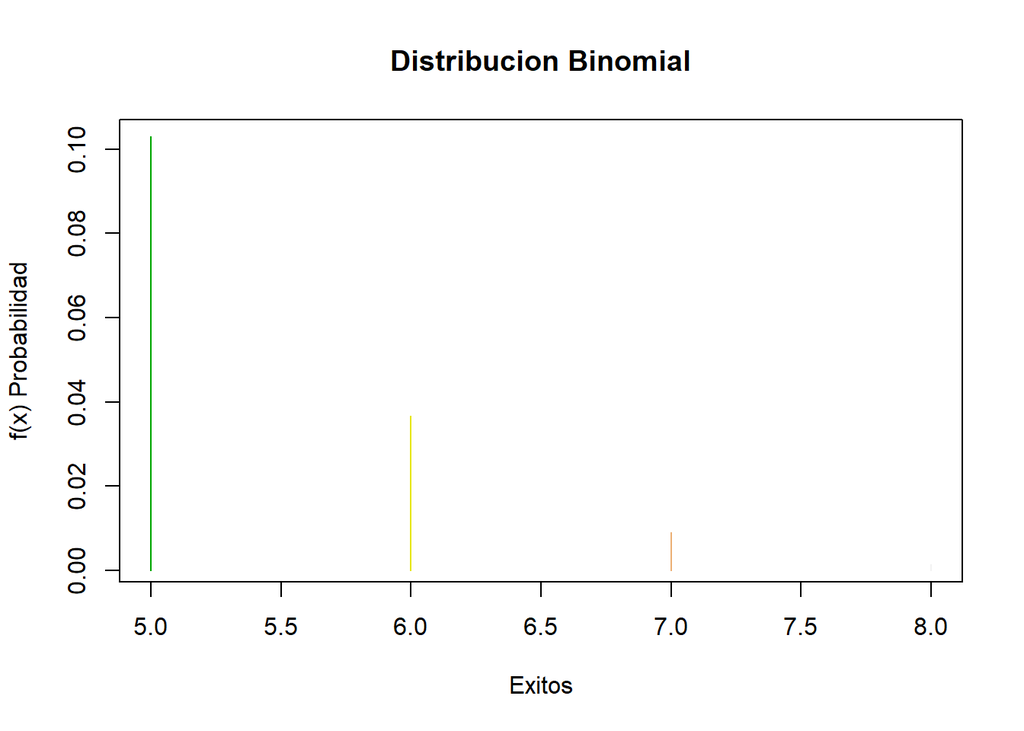

```r
#usando dbinom
prob <- dbinom(c(5:8), size = 10, prob = 0.3)
plot(c(5:8), prob, type="h", xlab="Exitos", ylab="f(x) Probabilidad", main="Distribucion Binomial", col=terrain.colors(4))
```

```r
sum(prob)
```

```
## [1] 0.1501246
```

```r
#usando pbinom
pbinom(8, size = 10, prob = 0.3) - pbinom(4, size = 10, prob = 0.3)
```

```
## [1] 0.1501246
```

**d.** ¿Cuál es la probabilidad de que haya exactamente 5 mujeres en la muestra?

```r
prob <- dbinom(5, size = 10, prob = 0.3)
prob
```

```
## [1] 0.1029193
```

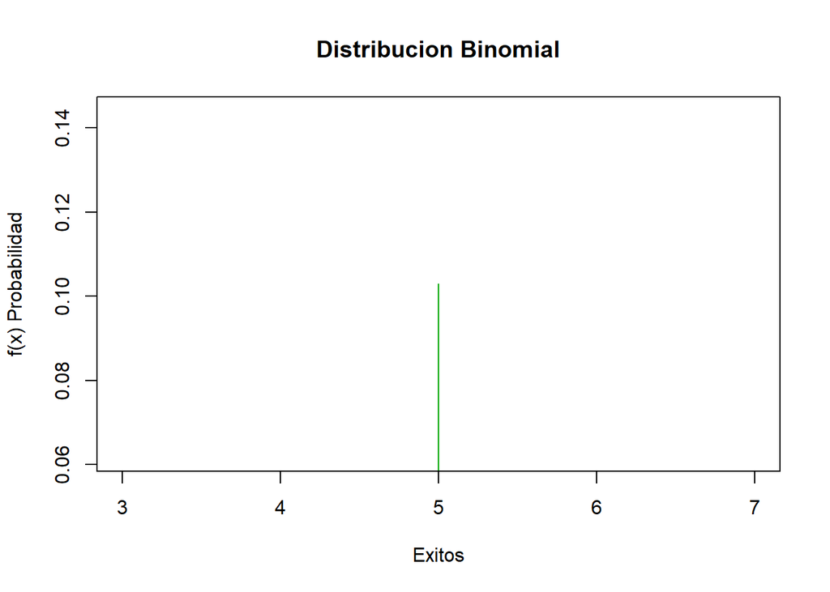

```r
plot(5, prob, type="h", xlab="Exitos", ylab="f(x) Probabilidad", main="Distribucion Binomial", col=terrain.colors(4))
```

**e.** Determine la media y la desviación estándar que se esperaría ver en la muestra.

```r
media <- 10*0.3
varianza <- 10*0.3*0.7
des.est <- round(sqrt(varianza), 4)
sprintf("Media %s:", media)
```

```
## [1] "Media 3:"
```

```r
sprintf("Varianza %s:", varianza)
```

```
## [1] "Varianza 2.1:"
```

```r
sprintf("Desviacion Estandar %s:", des.est)
```

```
## [1] "Desviacion Estandar 1.4491:"
```

**2.** Constantemente, la gente que posee un vehículo vive quejándose de las fallas mecánicas que estos presentan, tanto, porque es un gasto tanto para sus bolsillos como por las implicaciones en la disponibilidad de uso. Popularmente, se tiene la creencia de que una persona podría olvidarse de este tipo de imprevistos si tuviese la capacidad de pago para adquirir un vehículo nuevo de agencia, situación que no es tan cierta. Suponga que en Costa Rica, la compañía de autos A debe hacer efectiva su garantía para algunos usuarios que adquirieron de agencia, uno de sus autos modelo X. Sabiendo que para el mes de enero pasado, disponía de 30 vehículos de dicho modelo X en sus agencias donde 3 de ellos venía con un desperfecto de fábrica y que durante ese mes logró vender 8 de esos autos, realice lo siguiente:

**a.** Verifique que se cumple la condición para que sea hipergeométrica y escriba la ecuación de la distribución que modela esta situación

Se cumple que la probabilidad de éxito cambia en cada ensayo, esta enfocada a experimentos sin reemplazo y es una población finita.

$$p(x)=\frac{\binom{S}{x}\binom{N-S}{n-x}}{\binom{N}{n}}$$

**b.** ¿Cuál es la probabilidad de que ninguno de los autos vendidos requiera la garantía durante el primer año?.

```r
prob <- dhyper(8, m = 27, n = 3, k = 8)
prob
```

```
## [1] 0.3793103
```

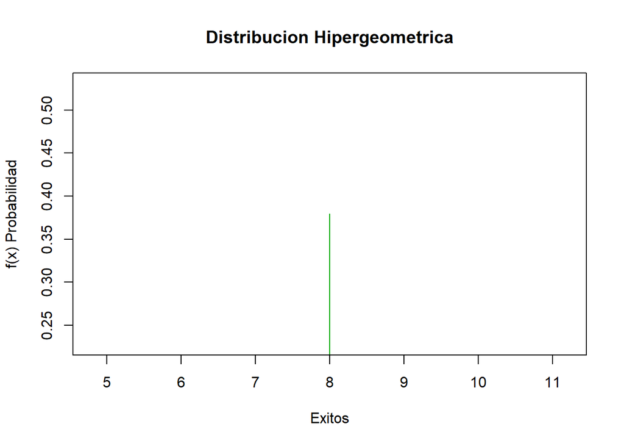

```r
plot(8, prob, type="h", xlab="Exitos", ylab="f(x) Probabilidad", main="Distribucion Hipergeometrica", col=terrain.colors(4))
```

**c.** Determine la probabilidad de que al menos dos de los autos vendidos requiera hacer uso de la garantía.

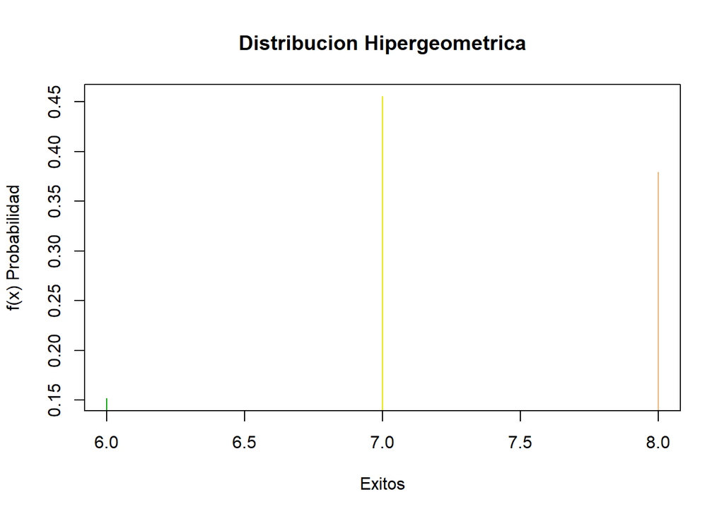

```r
#usando dhyper
prob <- dhyper(c(6:8), m = 27, n = 3, k = 8)
plot(c(6:8), prob, type="h", xlab="Exitos", ylab="f(x) Probabilidad", main="Distribucion Hipergeometrica", col=terrain.colors(4))
```

```r
sum(prob)
```

```
## [1] 0.9862069
```

```r
#usando phyper
phyper(5, m = 27, n = 3, k = 8, lower.tail = FALSE)
```

```
## [1] 0.9862069
```

*Media, varianza y Desviacion Estandar*

```r
media <- round((8*27)/30, 4)
varianza <- round(((8*27)*(30-27)*(30-8))/(30**2*(30-1)), 4)
des.est <- round(sqrt(varianza), 4)
sprintf("Media %s:", media)
```

```
## [1] "Media 7.2:"
```

```r
sprintf("Varianza %s:", varianza)
```

```
## [1] "Varianza 0.5462:"
```

```r
sprintf("Desviacion Estandar %s:", des.est)
```

```
## [1] "Desviacion Estandar 0.7391:"
```

**3.** Un juego consiste en girar una ruleta que tiene 3 opciones de premio y 13 opciones no premio. Una persona que juegue la ruleta ganará si al girarla obtiene la opción “premio” antes del cuarto intento.

**a.** Escriba la fórmula de la distribución que modela esta situación

$$g(y;p)=p(y)=pq^{y-1}, y = 1,2,3,...$$

**b.** Calcule la probabilidad de si una persona gane en una jugada en la ruleta.

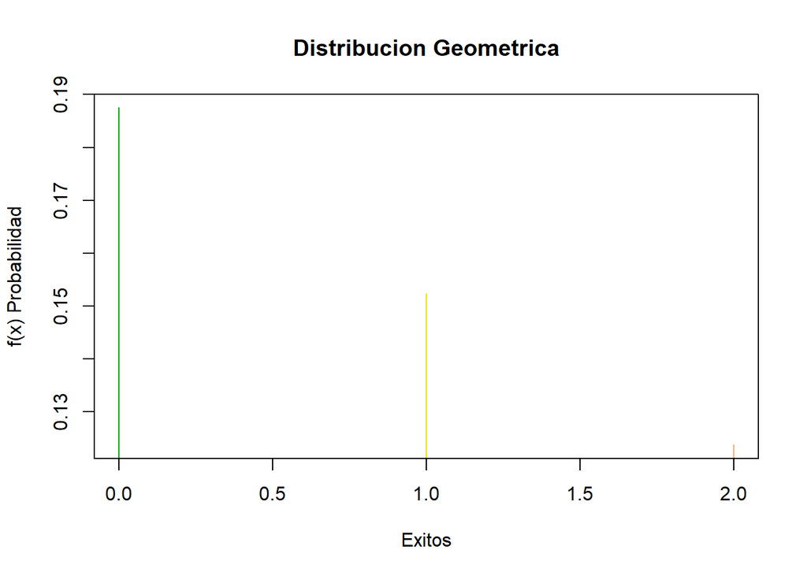

```r
#usando dgeom
prob <- dgeom(c(0:2), prob = 0.1875)
plot(c(0:2), prob, type="h", xlab="Exitos", ylab="f(x) Probabilidad", main="Distribucion Geometrica", col=terrain.colors(4))
```

```r
sum(prob)
```

```
## [1] 0.463623
```

```r
#usando pgeom
pgeom(2, prob = 0.1875)
```

```
## [1] 0.463623
```

*Media, varianza y Desviacion Estandar*

```r
media <- round(1/0.1875, 4)
varianza <- round((1-0.1875)/0.1875**2, 4)
des.est <- round(sqrt(varianza), 4)
sprintf("Media %s:", media)
```

```
## [1] "Media 5.3333:"
```

```r
sprintf("Varianza %s:", varianza)
```

```
## [1] "Varianza 23.1111:"
```

```r
sprintf("Desviacion Estandar %s:", des.est)
```

```
## [1] "Desviacion Estandar 4.8074:"
```